# Introduction

### 2.Several sepal_length_cm entries for Iris-versicolor have near-zero values

```python
#Moving on second problem. Lets first have a look at those enteries
df.loc[(df['class'] == 'Iris-versicolor') &
              (df['sepal_length_cm'] < 1.0)]
```

|  | sepal_length_cm | sepal_width_cm | petal_length_cm | petal_width_cm | class |
| --- | --- | --- | --- | --- | --- |
| 77 | 0.067 | 3.0 | 5.0 | 1.7 | Iris-versicolor |
| 78 | 0.060 | 2.9 | 4.5 | 1.5 | Iris-versicolor |
| 79 | 0.057 | 2.6 | 3.5 | 1.0 | Iris-versicolor |
| 80 | 0.055 | 2.4 | 3.8 | 1.1 | Iris-versicolor |
| 81 | 0.055 | 2.4 | 3.7 | 1.0 | Iris-versicolor |

Now it seems that values are factored by 1/100 due to some reason. Lets correct it.

```python
# Correcting the values for 'Iris-versicolor'
df.loc[(df['class'] == 'Iris-versicolor') &
              (df['sepal_length_cm'] < 1.0),
              'sepal_length_cm'] *= 100.0
```

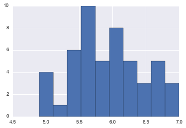

```python
# Lets have a quick look at the histogram
df.loc[df["class"]== "Iris-versicolor", "sepal_length_cm"].hist()
```

### Now moving towards the problem of null values

```python
#Lets have a look first
df.loc[(df["petal_width_cm"].isnull())]
```

[output not shown]

Its not a good idea to drop those enteries from the database. Lets replace the null values with mean values

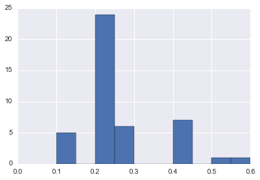

```python
#Plotting the histogram
df.loc[(df["class"]=="Iris-setosa"),'petal_width_cm'].hist()
```

```python
#Lets check the mean
df.loc[(df["class"]=="Iris-setosa"),'petal_width_cm'].mean()
```

```
0.24999999999999997
```

```python
#Replacing the null values with mean
df.loc[(df["petal_width_cm"].isnull()),"petal_width_cm"] = 0.25
```

```python
#Nowlet us put the tidy dataset in a new file
df.to_csv('iris-data-clean.csv', index=False)

df_clean = pd.read_csv('iris-data-clean.csv')
```

## Exploratory Data Analysis(EDA)

After cleaning the dataset it isimportant to do some exploratory analysis to find relations between various parameters. It is important since it helps while preparing the model for our dataset.

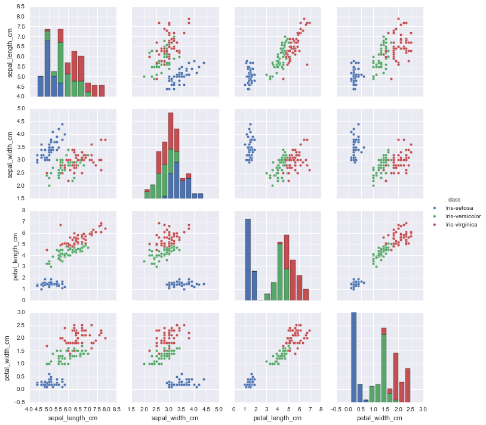

```python
#pairplot to study relationship between various parameters
sns.pairplot(df_clean, hue ="class")
```

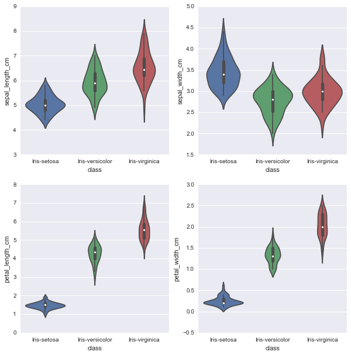

```python
#We can also make violin plots of the data to compare the measurement distributions of the classes.
plt.figure(figsize=(10, 10))

for column_index, column in enumerate(df_clean.columns):
    if column == 'class':
        continue
    plt.subplot(2, 2, column_index + 1)
    sns.violinplot(x='class', y=column, data=df_clean)
```

# Classification

Lets first divide our dataset into training and test dataset. But, before that we have to first convert them into lists.

```python
iris_data_clean = pd.read_csv('iris-data-clean.csv')

# We're using all four measurements as inputs
# Extract the data in list format from pandas:
all_inputs = iris_data_clean[['sepal_length_cm', 'sepal_width_cm',
                             'petal_length_cm', 'petal_width_cm']].values

# Similarly,extracting the classes
all_classes = iris_data_clean['class'].values

# Here's what a subset of our inputs looks like:
all_inputs[:5]
```

```
array([[ 5.1,  3.5,  1.4,  0.2],
       [ 4.9,  3. ,  1.4,  0.2],
       [ 4.7,  3.2,  1.3,  0.2],
       [ 4.6,  3.1,  1.5,  0.2],
       [ 5. ,  3.6,  1.4,  0.2]])
```

```python
# Now letssplit our dataset on training and test data
from sklearn.cross_validation import train_test_split

(training_inputs,
 testing_inputs,
 training_classes,
 testing_classes) = train_test_split(all_inputs, all_classes, train_size=0.75, random_state=1)
```

Lets use decision tree classifier for our problem.

```python
#Importing decision tree classifier from sklearn.tree
from sklearn.tree import DecisionTreeClassifier

# Create the classifier
decision_tree_classifier = DecisionTreeClassifier()

# Train the classifier on the training set
decision_tree_classifier.fit(training_inputs, training_classes)

# Validate the classifier on the testing set using classification accuracy
decision_tree_classifier.score(testing_inputs, testing_classes)
```

```
0.97368421052631582
```

Our model achieves 97% classification accuracy without much effort. But,Depending on how our training and testing set was sampled, our model can achieve anywhere from 80% to 100% accuracy. Lets see if there is problem of over-fitting

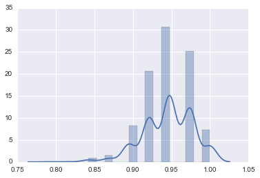

```python
model_accuracies = []

for repetition in range(1000):
    (training_inputs,
     testing_inputs,
     training_classes,
     testing_classes) = train_test_split(all_inputs, all_classes, train_size=0.75)

    decision_tree_classifier = DecisionTreeClassifier()
    decision_tree_classifier.fit(training_inputs, training_classes)
    classifier_accuracy = decision_tree_classifier.score(testing_inputs, testing_classes)
    model_accuracies.append(classifier_accuracy)

sns.distplot(model_accuracies)
```

The model performs differently on different datasets. It clearly due to over fitting. Lets use k fold cross validation

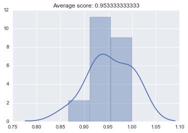

```python
#importing cross_val_score
from sklearn.cross_validation import cross_val_score

decision_tree_classifier = DecisionTreeClassifier()

# cross_val_score returns a list of the scores, which we can visualize
# to get a reasonable estimate of our classifier's performance
cv_scores = cross_val_score(decision_tree_classifier, all_inputs, all_classes, cv=10)
sns.distplot(cv_scores)
plt.title('Average score: {}'.format(np.mean(cv_scores)))
```

## Parameter tuning

```python
#Using grid search for parameter tuning
from sklearn.cross_validation import StratifiedKFold
from sklearn.grid_search import GridSearchCV

decision_tree_classifier = DecisionTreeClassifier()

parameter_grid = {'max_depth': [1, 2, 3, 4, 5],
                  'max_features': [1, 2, 3, 4]}

cross_validation = StratifiedKFold(all_classes, n_folds=10)

grid_search = GridSearchCV(decision_tree_classifier,
                           param_grid=parameter_grid,
                           cv=cross_validation)

grid_search.fit(all_inputs, all_classes)
print('Best score: {}'.format(grid_search.best_score_))
print('Best parameters: {}'.format(grid_search.best_params_))
```

```
Best score: 0.959731543624
Best parameters: {'max_features': 4, 'max_depth': 3}
```

```python
Decision_tree_classifier = DecisionTreeClassifier()

parameter_grid = {'criterion': ['gini', 'entropy'],
                  'splitter': ['best', 'random'],
                  'max_depth': [1, 2, 3, 4, 5],
                  'max_features': [1, 2, 3, 4]}

cross_validation = StratifiedKFold(all_classes, n_folds=10)

grid_search = GridSearchCV(decision_tree_classifier,
                           param_grid=parameter_grid,
                           cv=cross_validation)

grid_search.fit(all_inputs, all_classes)
print('Best score: {}'.format(grid_search.best_score_))
print('Best parameters: {}'.format(grid_search.best_params_))
```

```
Best score: 0.96644295302
Best parameters: {'max_features': 3, 'splitter': 'best', 'criterion': 'entropy', 'max_depth': 3}
```

Now we can take the best classifier from the Grid Search and use that:

```python
decision_tree_classifier = grid_search.best_estimator_
decision_tree_classifier
```

```
DecisionTreeClassifier(class_weight=None, criterion='entropy', max_depth=3,
            max_features=3, max_leaf_nodes=None, min_samples_leaf=1,
            min_samples_split=2, min_weight_fraction_leaf=0.0,
            presort=False, random_state=None, splitter='best')
```

#### Let's see if a Random Forest classifier works better here.

```python
from sklearn.ensemble import RandomForestClassifier

random_forest_classifier = RandomForestClassifier()

parameter_grid = {'n_estimators': [5, 10, 25, 50],
                  'criterion': ['gini', 'entropy'],
                  'max_features': [1, 2, 3, 4],
                  'warm_start': [True, False]}

cross_validation = StratifiedKFold(all_classes, n_folds=10)

grid_search = GridSearchCV(random_forest_classifier,
                           param_grid=parameter_grid,
                           cv=cross_validation)

grid_search.fit(all_inputs, all_classes)
print('Best score: {}'.format(grid_search.best_score_))
print('Best parameters: {}'.format(grid_search.best_params_))

grid_search.best_estimator_
```

```
Best score: 0.973154362416
Best parameters: {'max_features': 2, 'n_estimators': 10, 'criterion': 'gini', 'warm_start': True}
```

```
RandomForestClassifier(bootstrap=True, class_weight=None, criterion='gini',
            max_depth=None, max_features=2, max_leaf_nodes=None,
            min_samples_leaf=1, min_samples_split=2,
            min_weight_fraction_leaf=0.0, n_estimators=10, n_jobs=1,
            oob_score=False, random_state=None, verbose=0, warm_start=True)
```

Now we can compare their performance:

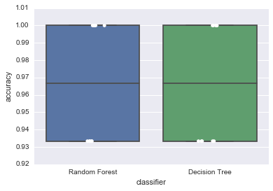

```python
random_forest_classifier = grid_search.best_estimator_

rf_df = pd.DataFrame({'accuracy': cross_val_score(random_forest_classifier, all_inputs, all_classes, cv=10),
                       'classifier': ['Random Forest'] * 10})
dt_df = pd.DataFrame({'accuracy': cross_val_score(decision_tree_classifier, all_inputs, all_classes, cv=10),
                      'classifier': ['Decision Tree'] * 10})
both_df = rf_df.append(dt_df)

sns.boxplot(x='classifier', y='accuracy', data=both_df)
sns.stripplot(x='classifier', y='accuracy', data=both_df, jitter=True, color='white')
```

## Lets make some predictions

```python
# some of the predictions from the classifier
(training_inputs,
 testing_inputs,
 training_classes,
 testing_classes) = train_test_split(all_inputs, all_classes, train_size=0.75)

random_forest_classifier.fit(training_inputs, training_classes)

for input_features, prediction, actual in zip(testing_inputs[:10],
                                              random_forest_classifier.predict(testing_inputs[:10]),
                                              testing_classes[:10]):
    print('{}\t-->\t{}\t(Actual: {})'.format(input_features, prediction, actual))
```

```
[ 5.1  3.5  1.4  0.2]	-->	Iris-setosa	(Actual: Iris-setosa)
[ 6.   3.4  4.5  1.6]	-->	Iris-versicolor	(Actual: Iris-versicolor)
[ 6.7  3.3  5.7  2.5]	-->	Iris-virginica	(Actual: Iris-virginica)
[ 5.5  2.4  3.8  1.1]	-->	Iris-versicolor	(Actual: Iris-versicolor)
[ 5.7  2.5  5.   2. ]	-->	Iris-virginica	(Actual: Iris-virginica)
[ 5.5  2.4  3.7  1. ]	-->	Iris-versicolor	(Actual: Iris-versicolor)
[ 5.3  3.7  1.5  0.2]	-->	Iris-setosa	(Actual: Iris-setosa)
[ 5.1  2.5  3.   1.1]	-->	Iris-versicolor	(Actual: Iris-versicolor)
[ 6.4  3.2  5.3  2.3]	-->	Iris-virginica	(Actual: Iris-virginica)
[ 7.3  2.9  6.3  1.8]	-->	Iris-virginica	(Actual: Iris-virginica)
```